# Final Exam

# Final Exam

- Date: 2020/1/6
- Class: Multivariate
- Student: R08631020 Lin, Hong-Ye

## Q1 Grade data Analysis

```r
set.seed(1)
data = read.csv("./GRADES.dat", header=T, sep="")
head(data)
```

```
##     Lab  HW PopQuiz Exam1 Exam2 FinalExam
## 1  9.95 9.4    8.13    72    90        62
## 2  7.71 0.0    8.00    63    26        78
## 3 10.00 9.5    8.13    79    55        80
## 4  9.95 9.4    8.88    89    77        79
## 5  9.95 9.2    8.50    83    84        67
## 6 10.00 9.9    9.63    96    94        93
```

### (a) Clustering

Using K-mean to cluster

```r
cl = kmeans(data, 3)
cl
```

```
## K-means clustering with 3 clusters of sizes 17, 41, 36
##
## Cluster means:
##        Lab       HW  PopQuiz    Exam1    Exam2 FinalExam
## 1 8.925882 7.191176 7.134706 63.11765 36.47059  54.35294
## 2 9.760000 8.951707 7.517805 76.21951 73.31707  71.63415
## 3 9.834722 9.426111 8.695833 90.00000 82.19444  86.88889
##
## Clustering vector:
##  [1] 2 1 2 3 2 3 3 2 3 2 1 1 3 2 2 3 3 1 1 2 2 2 3 3 2 3 2 3 2 2 3 3 3 2 3
## [36] 3 2 2 2 3 1 2 3 1 2 2 3 3 2 2 2 3 2 1 2 1 2 2 3 3 3 3 2 1 2 1 3 1 1 1
## [71] 2 3 3 3 3 1 2 3 2 2 1 2 3 2 1 2 2 3 3 2 3 2 2 3
##
## Within cluster sum of squares by cluster:
## [1] 9779.060 9167.408 5331.735
##  (between_SS / total_SS =  65.8 %)
##
## Available components:
##
## [1] "cluster"      "centers"      "totss"        "withinss"
## [5] "tot.withinss" "betweenss"    "size"         "iter"
## [9] "ifault"
```

And show the first two axis of PCA to evaluate the cluster.

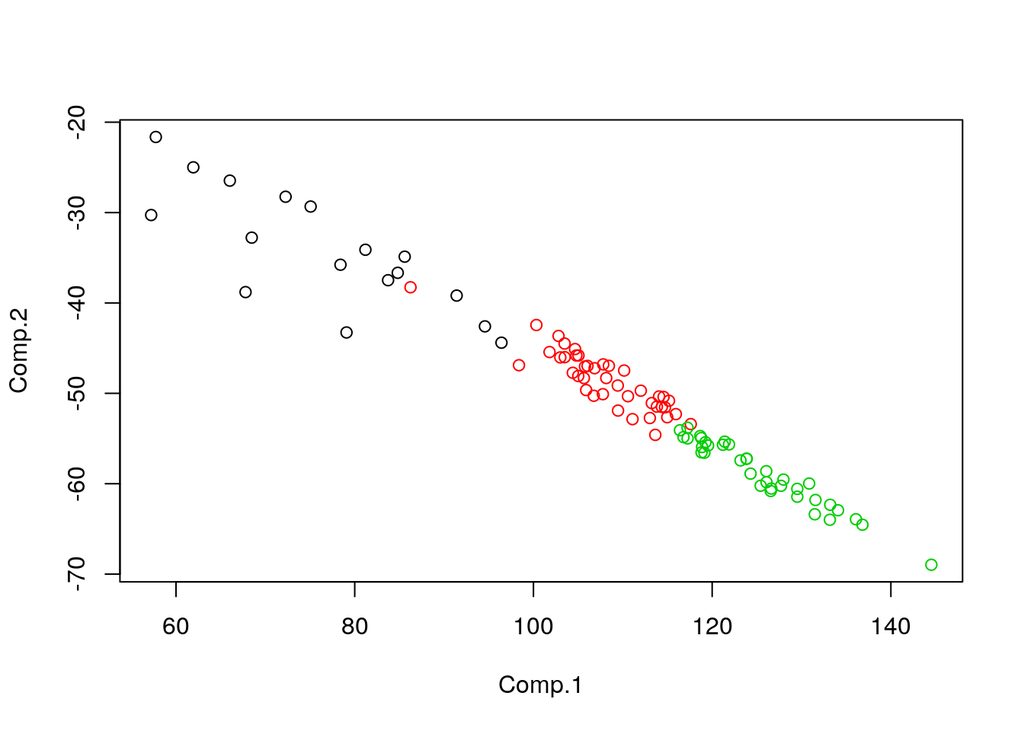

```r
pc_data = princomp(data ,cor=TRUE)
new_data = t(t(pc_data$loadings[, 1:2]) %*% t(as.matrix(data)))
plot(new_data,col=cl$cluster)
points(cl$centers, col=1:2, pch=8, cex=2)
```

And there mean performance in each cluster (Black, Red, Green)

```r
cl$centers
```

```
##        Lab       HW  PopQuiz    Exam1    Exam2 FinalExam
## 1 8.925882 7.191176 7.134706 63.11765 36.47059  54.35294
## 2 9.760000 8.951707 7.517805 76.21951 73.31707  71.63415
## 3 9.834722 9.426111 8.695833 90.00000 82.19444  86.88889
```

### (b) Factor Analysis

Perform FA

```r
library(psych)
set.seed(1)
data = read.csv("./GRADES.dat", header=T, sep="")
head(data)
```

```
##     Lab  HW PopQuiz Exam1 Exam2 FinalExam
## 1  9.95 9.4    8.13    72    90        62
## 2  7.71 0.0    8.00    63    26        78
## 3 10.00 9.5    8.13    79    55        80
## 4  9.95 9.4    8.88    89    77        79
## 5  9.95 9.2    8.50    83    84        67
## 6 10.00 9.9    9.63    96    94        93
```

```r
data_cor = head(data)
fa_data = principal(data_cor, nfactors=4, rotate='varimax')
print(fa_data$loading, cutoff=.5)
```

```
##
## Loadings:
##           RC1    RC2    RC3    RC4
## Lab        0.977
## HW         0.972
## PopQuiz           0.733  0.599
## Exam1      0.614  0.616
## Exam2      0.726         0.688
## FinalExam         0.995
##
##                  RC1   RC2   RC3   RC4
## SS loadings    2.890 1.914 1.070 0.126
## Proportion Var 0.482 0.319 0.178 0.021
## Cumulative Var 0.482 0.801 0.979 1.000
```

You can see the result show that Lab score has high correlated to HW, exam1 and exam2.

Popquiz is related to exam1 and finalexam. Also in other component, it related to exam2.

And in the scree plot, choosing three factors is enough.

```r
a = colSums(fa_data$loadings ^2)
a$sdev = colSums(fa_data$loadings ^2)
```

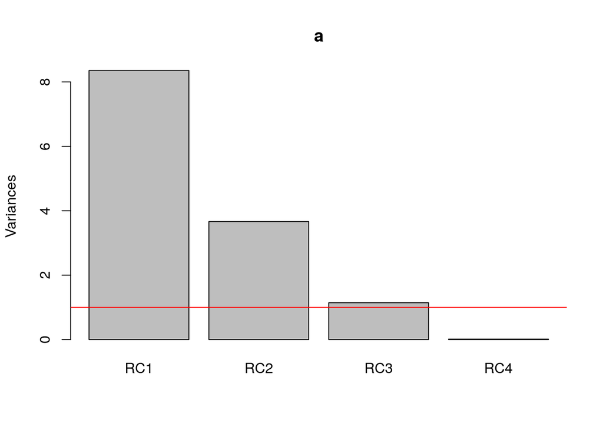

```r
screeplot(a)
abline(h=1, col="red")
```

## Q2 Grade data Analysis

```r
set.seed(1)
data = read.csv("./GRADES.dat", header=T, sep="")
head(data)
```

```
##     Lab  HW PopQuiz Exam1 Exam2 FinalExam
## 1  9.95 9.4    8.13    72    90        62
## 2  7.71 0.0    8.00    63    26        78
## 3 10.00 9.5    8.13    79    55        80
## 4  9.95 9.4    8.88    89    77        79
## 5  9.95 9.2    8.50    83    84        67
## 6 10.00 9.9    9.63    96    94        93
```

```r
d = dist(data)
```

### (a)(b) Clustering and find the minial

Using hclust to cluster to two groups by each method.

```r
method = c("ward.D", "ward.D2", "single", "complete", "average", "median", "mcquitty", "centroid")

for (i in 1:length(method)) {
    dc = hclust(d, method=method[i])
    memb = cutree(dc, k = 2)
    d1 = colMeans(data[memb == 1,])
    d2 = colMeans(data[memb == 2,])
    dd = t(data.frame(d1, d2))
    dd = data.frame(dd, len=c(sum(memb == 1), sum(memb == 2)))
    print(method[i])
    print(dd)
}
```

```
## [1] "ward.D"
##         Lab       HW  PopQuiz    Exam1    Exam2 FinalExam len
## d1 9.795062 9.180741 8.052963 82.29630 76.03704  77.90123  81
## d2 8.657692 6.536154 6.944615 59.38462 32.76923  52.23077  13
## [1] "ward.D2"
##         Lab       HW  PopQuiz    Exam1    Exam2 FinalExam len
## d1 9.794935 9.173506 8.068571 82.66234 77.46753  78.76623  77
## d2 8.925882 7.191176 7.134706 63.11765 36.47059  54.35294  17
## [1] "single"
##         Lab       HW  PopQuiz    Exam1    Exam2 FinalExam len
## d1 9.635376 8.813011 7.913333 79.35484 70.58065   74.8172  93
## d2 9.860000 9.000000 6.630000 58.00000 21.00000   31.0000   1
## [1] "complete"
##         Lab       HW  PopQuiz    Exam1    Exam2 FinalExam len
## d1 9.794935 9.173506 8.068571 82.66234 77.46753  78.76623  77
## d2 8.925882 7.191176 7.134706 63.11765 36.47059  54.35294  17
## [1] "average"
##         Lab       HW  PopQuiz    Exam1    Exam2 FinalExam len
## d1 9.794474 9.210789 8.062895 82.60526 77.73684  79.03947  76
## d2 8.976111 7.143889 7.210556 64.44444 37.61111  54.55556  18
## [1] "median"
##          Lab       HW   PopQuiz     Exam1     Exam2 FinalExam len
## d1  9.633871 8.803871  7.877097  78.90323  69.73118  74.07527  93
## d2 10.000000 9.850000 10.000000 100.00000 100.00000 100.00000   1
## [1] "mcquitty"
##         Lab       HW  PopQuiz    Exam1    Exam2 FinalExam len
## d1 9.795062 9.180741 8.052963 82.29630 76.03704  77.90123  81
## d2 8.657692 6.536154 6.944615 59.38462 32.76923  52.23077  13
## [1] "centroid"
##         Lab       HW  PopQuiz    Exam1    Exam2 FinalExam len
## d1 9.799333 9.271600 8.153733 83.01333 77.97333  79.17333  75
## d2 9.000000 7.012632 6.896842 63.78947 38.78947  55.31579  19
```

The result show that `ward.D` and `mcquitty` make the minial students to fail by the distance of those 6 dimensions. It only fail 13 students.

Or you use `single` to cut, only 1 students will fail, however his/her lab and homework is somewhat better than another groups.

## Q3 paper strength analysis

```r
set.seed(1)
data = read.csv("./strength.dat", header=T, sep="\t")
head(data)
```

```
##       X1    X2    X3    X4     Y1     Y2     Y3    Y4
## 1 21.312 7.039 5.326 0.932 -0.030 35.239 36.991 1.057
## 2 21.206 6.979 5.237 0.871  0.015 35.713 36.851 1.064
## 3 20.709 6.779 5.060 0.742  0.025 39.220 30.586 1.053
## 4 19.542 6.601 4.479 0.513  0.030 39.756 21.072 1.050
## 5 20.449 6.795 4.912 0.577 -0.070 32.991 36.570 1.049
## 6 20.841 6.919 5.108 0.784 -0.050 31.140 38.115 1.052
```

```r
X = data[, c("X1", "X2", "X3", "X4")]
Y = data[, c("Y1", "Y2", "Y3", "Y4")]
```

### (a) Canonical analysis

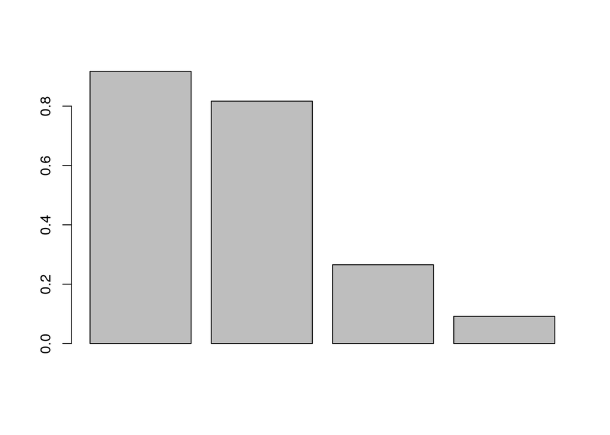

```r
library(CCA)
result <-cc(X, Y)
barplot(result$cor)
```

```r
# plt.cc(result)
"Correlation"
```

```
## [1] "Correlation"
```

```r
result$cor
```

```
## [1] 0.91732930 0.81692694 0.26538537 0.09168402
```

```r
"X loadings"
```

```
## [1] "X loadings"
```

```r
result$xcoef
```

```
##          [,1]       [,2]       [,3]       [,4]
## X1  0.5224426 -1.2131371   1.978681  1.7646646
## X2  0.2957899 -2.1536462  -4.920057  0.8188946
## X3 -1.3660328  0.7355096   3.222027 -4.1489040
## X4 -0.9760405  5.4369966 -10.321875  0.9899703
```

```r
"Y loadings"
```

```
## [1] "Y loadings"
```

```r
result$ycoef
```

```
##            [,1]          [,2]         [,3]         [,4]
## Y1   0.63837718  2.759453e+00  2.055673602 -9.349410148
## Y2  -0.04254049  6.745758e-02 -0.005191997  0.146642731
## Y3  -0.01850133  2.853256e-04  0.094704066 -0.001265821
## Y4 -27.73312447 -5.295920e+01 26.400088764 -3.022608981
```

We can find first two axis are good enough(have higher correlations).

### (b) Explain first variates of cca

Try to rotate the axis by first loadings.

```r
nx = as.matrix(X) %*% result$xcoef[, 1]
ny = as.matrix(Y) %*% result$ycoef[, 1]
n = data.frame(nx, ny)
```

Then, simply feed in to linear regression.

```r
fit = lm(ny ~ nx, n)
summary(fit)
```

```
##
## Call:
## lm(formula = ny ~ nx, data = n)
##
## Residuals:
##     Min      1Q  Median      3Q     Max
## -1.8875 -0.1556 -0.0088  0.2362  0.9058
##
## Coefficients:
##             Estimate Std. Error t value Pr(>|t|)
## (Intercept) -36.1596     0.2521 -143.45   <2e-16 ***
## nx            0.9173     0.0514   17.85   <2e-16 ***
## ---
## Signif. codes:  0 '***' 0.001 '**' 0.01 '*' 0.05 '.' 0.1 ' ' 1
##
## Residual standard error: 0.4014 on 60 degrees of freedom
## Multiple R-squared:  0.8415, Adjusted R-squared:  0.8389
## F-statistic: 318.5 on 1 and 60 DF,  p-value: < 2.2e-16
```

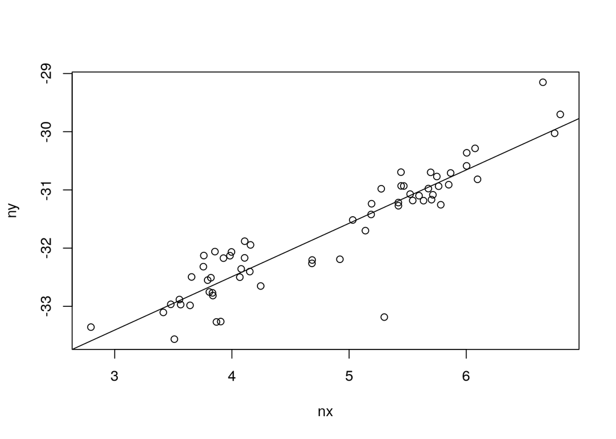

```r
plot(nx, ny)
abline(fit)
```

Where it’s $R^2$ is 0.8389, both p values of the slope and intercept are close to 0, so I think is a good measurment.

or you can evalute by testing

```r
n = nrow(data)
dimx = ncol(X)
dimy = ncol(Y)
# Bartlett's test
test =  -( n - 0.5 * (dimx + dimy + 3) ) * log(1 - result$cor[1])
"P value"
```

```
## [1] "P value"
```

```r
test_p = pchisq(test, df=dimx + dimy - 1 + 1, lower.tail=FALSE)
test_p
```

```
## [1] 1.580608e-26
```

Which get the same result as above that p value is close to 0.

## Q4 Food expendition Analysis

### (a) True

Rewrite the data. I separate the type and numbers of childrens `X` to `MA`, `CA`, `EM` and `num`.

```r
set.seed(1)
data = read.csv("./food.dat", header=T, sep=" ")

# Type: MA2 EM2 CA2 MA3 EM3 CA3 MA4 EM4 CA4 MA5 EM5 CA5
# I don't know how to split the sting in R so manually do it...
tp = factor(c("MA", "EM", "CA", "MA", "EM", "CA", "MA", "EM", "CA", "MA", "EM", "CA"))
data = cbind(data, num=c(2 ,2 ,2 ,3 ,3 ,3 ,4 ,4 ,4 ,5 ,5 ,5), MA=as.numeric(tp == "MA"), EM=as.numeric(tp == "EM"), CA=as.numeric(tp == "CA"))
data
```

```
##      X Bread Vegetables Fruit Meat Poultry Milk Wine num MA EM CA
## 1  MA2   332        428   354 1437     526  247  427   2  1  0  0
## 2  EM2   293        559   388 1527     567  239  258   2  0  1  0
## 3  CA2   372        767   562 1948     927  235  433   2  0  0  1
## 4  MA3   406        563   341 1507     544  324  407   3  1  0  0
## 5  EM3   386        608   396 1501     558  319  363   3  0  1  0
## 6  CA3   438        843   689 2345    1148  243  341   3  0  0  1
## 7  MA4   534        660   367 1620     638  414  407   4  1  0  0
## 8  EM4   460        699   484 1856     762  400  416   4  0  1  0
## 9  CA4   385        789   621 2366    1149  304  282   4  0  0  1
## 10 MA5   655        776   423 1848     759  495  486   5  1  0  0
## 11 EM5   584        995   548 2056     893  518  319   5  0  1  0
## 12 CA5   515       1097   887 2630    1167  561  284   5  0  0  1
```

### (b) Corresponse analysis

```r
# X = data[, c("num", "MA", "EM", "CA")]
X = data[, c("num", "MA", "EM", "CA")]
Y = data[,c("Bread", "Vegetables", "Fruit", "Meat", "Poultry", "Milk", "Wine")]

library("factoextra")
library("FactoMineR")
library("gplots")
fit <-CA(X, Y, graph = FALSE)
print(fit)
```

```
## **Results of the Correspondence Analysis (CA)**
## The row variable has  12  categories; the column variable has 4 categories
## The chi square of independence between the two variables is equal to 26.71071 (p-value =  0.7721964 ).
## *The results are available in the following objects:
##
##    name              description
## 1  "$eig"            "eigenvalues"
## 2  "$col"            "results for the columns"
## 3  "$col$coord"      "coord. for the columns"
## 4  "$col$cos2"       "cos2 for the columns"
## 5  "$col$contrib"    "contributions of the columns"
## 6  "$row"            "results for the rows"
## 7  "$row$coord"      "coord. for the rows"
## 8  "$row$cos2"       "cos2 for the rows"
## 9  "$row$contrib"    "contributions of the rows"
## 10 "$call"           "summary called parameters"
## 11 "$call$marge.col" "weights of the columns"
## 12 "$call$marge.row" "weights of the rows"
```

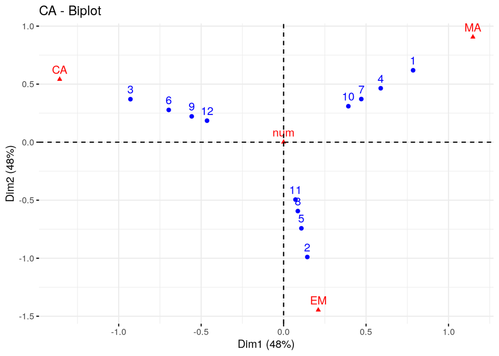

```r
fviz_ca_biplot(fit)
```

## Q5 Explain

### (a) MDS differ from Cluster and Factor Analysis

Multidimension scaling try to restore the coordinations from distance data. One of the advantage is that it can reduce the dimensions of data(Similar to FA), the other advantage is restoring corrdinate with the rank of distance not the real value of it’s distance, this is a little like clustering.

### (b) Clustering vs Factor Analysis

Cluster is trying to group the data by it’s distance usually.

Factor analysis is to find the latent feature of the data which show the relationship of them.